# STOPAS_Example_1

```python
import pandas as pd
import seaborn as sns
import matplotlib.pyplot as plt
import numpy as np
from sklearn.model_selection import train_test_split
from sklearn.linear_model import LinearRegression
import scipy.stats as stats
import statsmodels.api as sm
from sklearn.metrics import mean_absolute_error, mean_squared_error, r2_score
```

1-1.  
1-2.

```python
credit = pd.read_csv("CreditCard.csv")
```

```python
credit.head()
```

|  | rownames | card | reports | age | income | share | expenditure | owner | selfemp | dependents | months | majorcards | active |
| --- | --- | --- | --- | --- | --- | --- | --- | --- | --- | --- | --- | --- | --- |
| 0 | 1 | yes | 0 | 37.66667 | 4.5200 | 0.033270 | 124.983300 | yes | no | 3 | 54 | 1 | 12 |
| 1 | 2 | yes | 0 | 33.25000 | 2.4200 | 0.005217 | 9.854167 | no | no | 3 | 34 | 1 | 13 |
| 2 | 3 | yes | 0 | 33.66667 | 4.5000 | 0.004156 | 15.000000 | yes | no | 4 | 58 | 1 | 5 |
| 3 | 4 | yes | 0 | 30.50000 | 2.5400 | 0.065214 | 137.869200 | no | no | 0 | 25 | 1 | 7 |
| 4 | 5 | yes | 0 | 32.16667 | 9.7867 | 0.067051 | 546.503300 | yes | no | 2 | 64 | 1 | 5 |

```python
credit.describe()
```

|  | rownames | reports | age | income | share | expenditure | dependents | months | majorcards | active |
| --- | --- | --- | --- | --- | --- | --- | --- | --- | --- | --- |
| count | 1319.000000 | 1319.000000 | 1319.000000 | 1319.000000 | 1319.000000 | 1319.000000 | 1319.000000 | 1319.000000 | 1319.000000 | 1319.000000 |
| mean | 660.000000 | 0.456406 | 33.213103 | 3.365376 | 0.068732 | 185.057071 | 0.993935 | 55.267627 | 0.817286 | 6.996967 |
| std | 380.906813 | 1.345267 | 10.142783 | 1.693902 | 0.094656 | 272.218917 | 1.247745 | 66.271746 | 0.386579 | 6.305812 |
| min | 1.000000 | 0.000000 | 0.166667 | 0.210000 | 0.000109 | 0.000000 | 0.000000 | 0.000000 | 0.000000 | 0.000000 |
| 25% | 330.500000 | 0.000000 | 25.416670 | 2.243750 | 0.002316 | 4.583333 | 0.000000 | 12.000000 | 1.000000 | 2.000000 |
| 50% | 660.000000 | 0.000000 | 31.250000 | 2.900000 | 0.038827 | 101.298300 | 1.000000 | 30.000000 | 1.000000 | 6.000000 |
| 75% | 989.500000 | 0.000000 | 39.416670 | 4.000000 | 0.093617 | 249.035800 | 2.000000 | 72.000000 | 1.000000 | 11.000000 |
| max | 1319.000000 | 14.000000 | 83.500000 | 13.500000 | 0.906320 | 3099.505000 | 6.000000 | 540.000000 | 1.000000 | 46.000000 |

1-3.  
*The dataset here shows information relating to the holders of credit cards. For example, any derogatory marks, ratio of spending to income, own/rent, dependents, and more. All of which can be considered relevant information in determining someone’s creditworthiness.*

```python
credit.shape
```

```
(1319, 13)
```

1-4.  
*The file starts at 1319 rows by 13 columns (one of the columns, rownames, is simply just a running count and contains no information relevant to creditworthiness)*

```python
# 1-5.

train_set, test_set = train_test_split(credit, test_size=0.4, random_state=49)
```

```python
train_set.head()
```

|  | rownames | card | reports | age | income | share | expenditure | owner | selfemp | dependents | months | majorcards | active |
| --- | --- | --- | --- | --- | --- | --- | --- | --- | --- | --- | --- | --- | --- |
| 645 | 646 | yes | 0 | 29.33333 | 3.500 | 0.125741 | 366.7450 | no | no | 0 | 19 | 1 | 0 |
| 615 | 616 | no | 0 | 35.58333 | 4.000 | 0.000300 | 0.0000 | no | no | 2 | 70 | 1 | 1 |
| 922 | 923 | no | 11 | 24.75000 | 2.300 | 0.000522 | 0.0000 | no | no | 0 | 24 | 1 | 12 |
| 347 | 348 | no | 2 | 40.00000 | 2.400 | 0.000500 | 0.0000 | no | no | 0 | 72 | 1 | 6 |
| 694 | 695 | yes | 0 | 28.83333 | 2.184 | 0.079565 | 144.6417 | yes | no | 0 | 5 | 1 | 14 |

```python
train_set.shape
```

```
(791, 13)
```

```python
test_set.head()
```

|  | rownames | card | reports | age | income | share | expenditure | owner | selfemp | dependents | months | majorcards | active |
| --- | --- | --- | --- | --- | --- | --- | --- | --- | --- | --- | --- | --- | --- |
| 176 | 177 | yes | 0 | 23.58333 | 3.9 | 0.018305 | 58.99083 | no | no | 1 | 14 | 1 | 7 |
| 430 | 431 | yes | 0 | 63.16667 | 5.5 | 0.020482 | 93.62500 | yes | no | 1 | 192 | 1 | 15 |
| 1257 | 1258 | yes | 0 | 38.16667 | 5.1 | 0.021309 | 90.06333 | no | no | 0 | 60 | 1 | 7 |
| 300 | 301 | yes | 2 | 38.58333 | 4.0 | 0.113960 | 379.86580 | no | no | 0 | 120 | 1 | 8 |
| 327 | 328 | no | 2 | 28.33333 | 3.3 | 0.000364 | 0.00000 | no | no | 1 | 36 | 1 | 17 |

```python
test_set.shape
```

```
(528, 13)
```

1-6.  
*One of the main reasons a partition is created is to help avoid overfitting. The model is created using the training set, then the test set is deployed using data of which has been previously unseen. This improves the model’s ability to assess new information.*

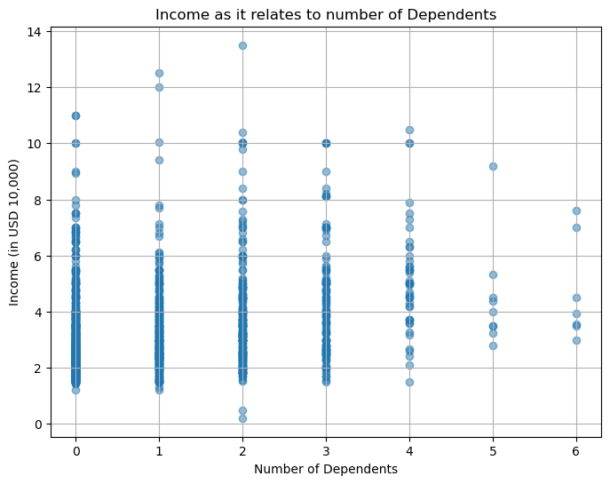

```python
# 1-1a

plt.figure(figsize=(8,6))
plt.scatter(credit['dependents'], credit['income'], alpha=0.5)
plt.xlabel('Number of Dependents')
plt.ylabel('Income (in USD 10,000)')
plt.title('Income as it relates to number of Dependents')
plt.grid(True)
plt.show()
```

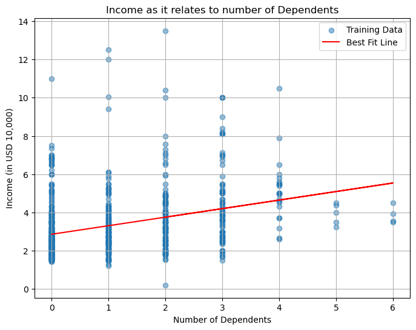

```python
# 1-2a

x_train = train_set['dependents']
y_train = train_set['income']

m, b = np.polyfit(x_train, y_train, 1)

plt.figure(figsize=(8,6))
plt.scatter(x_train, y_train, alpha=0.5, label="Training Data")
plt.plot(x_train, m*x_train + b, color='red', label="Best Fit Line")
plt.xlabel('Number of Dependents')
plt.ylabel('Income (in USD 10,000)')
plt.title('Income as it relates to number of Dependents')
plt.legend()
plt.grid(True)
plt.show()
```

1-3a.  
*The plot suggests that more dependents equate to higher incomes. Yes, this is generally intuitive – those with more dependents tend to have higher incomes (out of necessity). Interestingly, as per the scatter plot using the training set, beyond 4 dependents (i.e. 5 and 6) the incomes start to drop.*

```python
x_train = train_set['dependents']
y_train = train_set['income']

correlation, p_value = stats.pearsonr(x_train, y_train)

correlation_table = pd.DataFrame({
    "Measured": ["Correlation", "P-Value"],
    "Value": [f"{correlation:.6f}", f"{p_value:.6e}"]
})

print(correlation_table.to_string(index=False))
```

```
   Measured        Value
Correlation     0.334136
    P-Value 4.386392e-22
```

1-4a.  
*The correlation of income and dependents using the training set is 0.33. This indicates a positive weak to moderate/weak relationship between the two variables. So no, it is not a strong one. However, it is certainly significant with a P-value of (essentially) zero.*

```python
x_train_credit = pd.DataFrame(x_train)

model = LinearRegression()
model.fit(x_train_credit, y_train)

print(f"Intercept: {model.intercept_}")
print(f"Coefficient: {model.coef_[0]}")
```

```
Intercept: 2.863379332606768
Coefficient: 0.44636187472292016
```

```python
for d in range(0, 6):
    manual_calc = model.intercept_ + model.coef_[0] * d
    print(f"Dependents: {d} -> Predicted Income: ${manual_calc * 10000:,.2f}")
```

```
Dependents: 0 -> Predicted Income: $28,633.79
Dependents: 1 -> Predicted Income: $33,097.41
Dependents: 2 -> Predicted Income: $37,561.03
Dependents: 3 -> Predicted Income: $42,024.65
Dependents: 4 -> Predicted Income: $46,488.27
Dependents: 5 -> Predicted Income: $50,951.89
```

1-5a.  
*The model is saying that for someone with zero dependents a baseline income of \$28,634 per year is projected (the y-intercept equal to 2.8634) and that per every additional dependent approximately \$4,464 of extra income is anticipated (coefficient equal to 0.4464).*

```python
y_pred_train = pd.Series(model.predict(x_train_credit), index=x_train_credit.index)

residuals = y_train - y_pred_train

min_residual = residuals.min()
max_residual = residuals.max()

print(f"Minimum Residual: {min_residual}")
print(f"Maximum Residual: {max_residual}")
```

```
Minimum Residual: -3.5461030820526083
Maximum Residual: 9.743896917947392
```

1-6.  
*The residuals here show that in some cases the model overestimated income (min: -3.55 or by \$35,500) and in others underestimated the income (max: 9.74 or by $97,400). This can also be seen visually on the scatterplot, where the extreme residual values may represent rare cases and/or potential outliers.*

```python
max_residual_index = residuals.idxmax()

num_dependents = x_train.loc[max_residual_index]
actual_income = y_train.loc[max_residual_index]
highest_residual = residuals.loc[max_residual_index]

predicted_income = y_pred_train.loc[max_residual_index]

formatted_predicted = f"${predicted_income * 10000:,.2f}"
formatted_actual = f"${actual_income * 10000:,.2f}"

print(f"Highest Residual: {highest_residual}")
print(f"Predicted Income: {formatted_predicted}")
print(f"Actual Income: {formatted_actual}")
print(f"Number of Dependents: {num_dependents}")
```

```
Highest Residual: 9.743896917947392
Predicted Income: $37,561.03
Actual Income: $135,000.00
Number of Dependents: 2
```

1-7a.  
*The person with the highest residual (9.74) has an income of \$135,000 and 2 dependents. The model here predicts incomes of \$37,561.03 for all individuals with 2 dependents. The residual is calculated by taking the difference between actual less (-) expected.*

```python
min_residual_index = residuals.idxmin()

num_dependents = x_train.loc[min_residual_index]
actual_income = y_train.loc[min_residual_index]
lowest_residual = residuals.loc[min_residual_index]

predicted_income = y_pred_train.loc[min_residual_index]

formatted_predicted = f"${predicted_income * 10000:,.2f}"
formatted_actual = f"${actual_income * 10000:,.2f}"

print(f"Lowest Residual: {lowest_residual}")
print(f"Predicted Income (From Model): {formatted_predicted}")
print(f"Actual Income: {formatted_actual}")
print(f"Number of Dependents: {num_dependents}")
```

```
Lowest Residual: -3.5461030820526083
Predicted Income (From Model): $37,561.03
Actual Income: $2,100.00
Number of Dependents: 2
```

1-8a.  
*The person with the lowest residual (-3.55) has an income of \$2,100 and 2 dependents. The model predicts an income of \$37,561.03 for individuals with 2 dependents. The residual is calculated by taking the difference between actual less (-) expected, in this case resulting in a negative number.*

1-9a.  
*Dependents is certainly a reasonable starting point, and it is logical to assume that larger households will generally have a higher incomes than smaller ones; on a needs-based basis (purely out of necessity). The reason why this can’t be true all of the time generally comes down to a variety of occupations in the marketplace and salary differences between them, lifestyle choices, education, opportunities within one’s community, and even housing configurations. All of these can be a factors in actual realized ‘family size’ for individual households. In other words, it certainly isn’t ‘cut and dry’ and I can confidently state that income isn’t something that’s easy to draw a straight line through. Although, a relationship does exist with the variables in the dataset - as seen in the correlation section of this report.*

```python
# 2-1

correlation_variables = ['reports', 'age', 'income', 'share', 'expenditure',
                         'dependents', 'months', 'majorcards', 'active']

correlation_matrix = train_set[correlation_variables].corr()

print(correlation_matrix)
```

```
              reports       age    income     share  expenditure  dependents  \
reports      1.000000  0.062205 -0.003811 -0.165457    -0.138110    0.015637
age          0.062205  1.000000  0.306759 -0.118857     0.022740    0.217268
income      -0.003811  0.306759  1.000000 -0.044371     0.308940    0.334136
share       -0.165457 -0.118857 -0.044371  1.000000     0.827940   -0.080279
expenditure -0.138110  0.022740  0.308940  0.827940     1.000000    0.066575
dependents   0.015637  0.217268  0.334136 -0.080279     0.066575    1.000000
months       0.085351  0.409422  0.083427 -0.034468    -0.017920    0.051119
majorcards   0.008055 -0.012279  0.106704  0.036190     0.062449   -0.022040
active       0.202477  0.210681  0.155918  0.013148     0.095015    0.106381

               months  majorcards    active
reports      0.085351    0.008055  0.202477
age          0.409422   -0.012279  0.210681
income       0.083427    0.106704  0.155918
share       -0.034468    0.036190  0.013148
expenditure -0.017920    0.062449  0.095015
dependents   0.051119   -0.022040  0.106381
months       1.000000   -0.070300  0.124850
majorcards  -0.070300    1.000000  0.148534
active       0.124850    0.148534  1.000000
```

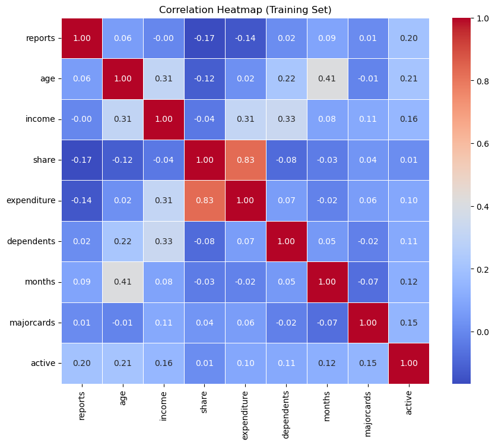

```python
plt.figure(figsize=(10, 8))

sns.heatmap(correlation_matrix, annot=True, cmap="coolwarm", fmt=".2f", linewidths=0.5)

plt.title("Correlation Heatmap (Training Set)")

plt.show()
```

2-2.  
*Yes, share (ratio of monthly credit card expenditure to yearly income) and expenditure (average monthly credit card expenditure) have a risk of multicollinearity with the positive and very strong correlation of 0.83.*

```python
# 2-3

correlation_variables_2 = ['reports', 'age', 'income', 'share',
                         'dependents', 'months', 'majorcards', 'active']

correlation_matrix_2 = train_set[correlation_variables_2].corr()

print(correlation_matrix_2)
```

```
             reports       age    income     share  dependents    months  \
reports     1.000000  0.062205 -0.003811 -0.165457    0.015637  0.085351
age         0.062205  1.000000  0.306759 -0.118857    0.217268  0.409422
income     -0.003811  0.306759  1.000000 -0.044371    0.334136  0.083427
share      -0.165457 -0.118857 -0.044371  1.000000   -0.080279 -0.034468
dependents  0.015637  0.217268  0.334136 -0.080279    1.000000  0.051119
months      0.085351  0.409422  0.083427 -0.034468    0.051119  1.000000
majorcards  0.008055 -0.012279  0.106704  0.036190   -0.022040 -0.070300
active      0.202477  0.210681  0.155918  0.013148    0.106381  0.124850

            majorcards    active
reports       0.008055  0.202477
age          -0.012279  0.210681
income        0.106704  0.155918
share         0.036190  0.013148
dependents   -0.022040  0.106381
months       -0.070300  0.124850
majorcards    1.000000  0.148534
active        0.148534  1.000000
```

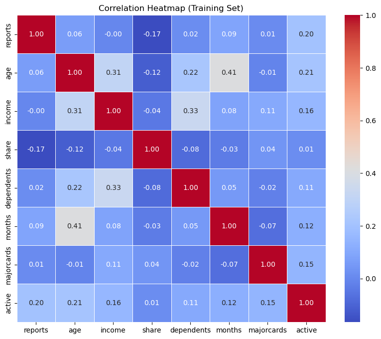

```python
plt.figure(figsize=(10, 8))

sns.heatmap(correlation_matrix_2, annot=True, cmap="coolwarm", fmt=".2f", linewidths=0.5)

plt.title("Correlation Heatmap (Training Set)")

plt.show()
```

2-4.  
*In this case I suppose I could have removed either one (share or expenditure) but have decided to remove the expenditure category. While estimating overall income is our primary goal, I feel the ratio of spending is a more valuable/consistent piece of information.*

```python
# 2-5

def backward_elimination(data, target, significance_level=0.05):

    X = data.copy()
    X = sm.add_constant(X)
    y = train_set[target]

    while True:
        model = sm.OLS(y, X).fit()

        max_p_value = model.pvalues.max()
        max_p_var = model.pvalues.idxmax()

        if max_p_value < significance_level:
            break

        print(f"Removing '{max_p_var}' with p-value {max_p_value:.4f}")
        X.drop(columns=[max_p_var], inplace=True)

    return model

correlation_variables_2 = ['reports', 'age', 'share', 'dependents', 'months', 'majorcards', 'active']
X_train = train_set[correlation_variables_2]
y_train = train_set['income']

final_model = backward_elimination(X_train, 'income')

print(final_model.summary())
```

```
Removing 'share' with p-value 0.8904
Removing 'months' with p-value 0.3894
Removing 'reports' with p-value 0.2537
Removing 'active' with p-value 0.0683
                            OLS Regression Results
==============================================================================
Dep. Variable:                 income   R-squared:                       0.183
Model:                            OLS   Adj. R-squared:                  0.180
Method:                 Least Squares   F-statistic:                     58.62
Date:                Sun, 06 Apr 2025   Prob (F-statistic):           3.30e-34
Time:                        10:25:39   Log-Likelihood:                -1446.9
No. Observations:                 791   AIC:                             2902.
Df Residuals:                     787   BIC:                             2920.
Df Model:                           3
Covariance Type:            nonrobust
==============================================================================
                 coef    std err          t      P>|t|      [0.025      0.975]
------------------------------------------------------------------------------
const          1.2252      0.212      5.782      0.000       0.809       1.641
age            0.0392      0.005      7.471      0.000       0.029       0.049
dependents     0.3782      0.044      8.573      0.000       0.292       0.465
majorcards     0.4945      0.137      3.598      0.000       0.225       0.764
==============================================================================
Omnibus:                      346.040   Durbin-Watson:                   2.001
Prob(Omnibus):                  0.000   Jarque-Bera (JB):             1905.354
Skew:                           1.932   Prob(JB):                         0.00
Kurtosis:                       9.548   Cond. No.                         149.
==============================================================================

Notes:
[1] Standard Errors assume that the covariance matrix of the errors is correctly specified.
```

2-5(cont.).  
*The multiple regression model here eliminates the share, months, reports, and active variables. The remaining variables are age, dependents, and majorcards resulting in the ‘new’ regression equation of* y =1.2252 + (0.0392 x age) + (0.3782 x dependents) + (0.4945 x majorcards). *The R-squared value of 0.183 indicates the model explains only 18.3% of the variability of income but with p-values of essentially zero, so is something - but not great.*

```python
# 2-1a

mean_income = y_train.mean()

SST = ((y_train - mean_income) ** 2).sum()

print(f"Total Sum of Squares (SST): {SST:.3f}")
```

```
Total Sum of Squares (SST): 2198.415
```

```python
# 2-2a

y_pred_train = final_model.fittedvalues

SSR = ((y_pred_train - mean_income) ** 2).sum()
print(f"Sum of Squares Due to Regression (SSR): {SSR:.3f}")
```

```
Sum of Squares Due to Regression (SSR): 401.513
```

```python
R_squared = SSR / SST
print(f"R-squared: {R_squared:.3f}")
```

```
R-squared: 0.183
```

2-3a.  
*Yep, this manual calculation is the same R-squared as listed in the model, so looking good here…*

```python
# 2-4a

t_value_majorcards = final_model.tvalues['majorcards']

print(f"T-value for 'majorcards': {t_value_majorcards:.3f}")
```

```
T-value for 'majorcards': 3.598
```

2-5a.  
*The model’s F-statistic is 58.62, which is fairly high. The number is telling us that our predictor variables significantly contribute to predicting income. The F-statistic compares a model with predictors to a model without:* F = (SSR/p) / (SSE/(n-p-1)) *The higher the number is, the more likely it is that the predictors applied contribute to the model's overall outcome.*

```python
# 2-6a

Mr_Jade = pd.DataFrame({
    'age': [57],
    'dependents': [0],
    'majorcards': [3]
})

Mr_Jade = sm.add_constant(Mr_Jade, has_constant='add')

predicted_income = final_model.predict(Mr_Jade)[0] * 10000

print(f"Predicted income for Mr. Jade: ${predicted_income:,.2f}")
```

```
Predicted income for Mr. Jade: $49,423.34
```

```python
# 2-7a

X_train_aligned = X_train[['age', 'dependents', 'majorcards']]
X_train_aligned = sm.add_constant(X_train_aligned, has_constant='add')

X_test_aligned = test_set[['age', 'dependents', 'majorcards']]
X_test_aligned = sm.add_constant(X_test_aligned, has_constant='add')

y_train = train_set['income']
y_test = test_set['income']

y_pred_train = final_model.predict(X_train_aligned)
y_pred_test = final_model.predict(X_test_aligned)


train_mae = mean_absolute_error(y_train, y_pred_train) * 10000
train_rmse = np.sqrt(mean_squared_error(y_train, y_pred_train)) * 10000
train_r2 = r2_score(y_train, y_pred_train)

test_mae = mean_absolute_error(y_test, y_pred_test) * 10000
test_rmse = np.sqrt(mean_squared_error(y_test, y_pred_test)) * 10000
test_r2 = r2_score(y_test, y_pred_test)

print(f"Training Set Metrics:")
print(f"MAE: ${train_mae:,.2f}")
print(f"RMSE: ${train_rmse:,.2f}")
print(f"R-squared: {train_r2:.4f}\n")

print(f"Test Set Metrics:")
print(f"MAE: ${test_mae:,.2f}")
print(f"RMSE: ${test_rmse:,.2f}")
print(f"R-squared: {test_r2:.4f}")
```

```
Training Set Metrics:
MAE: $10,351.20
RMSE: $15,072.11
R-squared: 0.1826

Test Set Metrics:
MAE: $10,878.82
RMSE: $15,761.64
R-squared: 0.1678
```

2-7a.  
*In this case both the Training Set and Test set are quite comparable in terms of mean absolute error, root mean squared error, and the r-squared values. The low r-squared(s) indicate there are likley a lot of other factors at play in determining actucal income, factors that are not measured in this particular dataset (in both cases the model can explain less than 20% of the results/variance: R-squared(s) < 0.2).*

2-7a. 2  
*Since everything (MAE, RMSE, R-squared) are fairly close to each other in both the training and test sets, there are no obvious signs of overfitting. When overfitting is present, these figures usually would be/should be much farther apart.*

2-7a. 3  
*The major limitations here are that the dataset can only ‘predict’ so much. There are a lot of other factors that go into what someone’s income may actually be (i.e. where they were born, where they live now, learned skills, natural skills, work ethic, behaviors, industry, and on). I’d imagine an occupation column would be a great predictor if it were to be added to this dataset ...zipcode also I'd expect to also have some strength.*